# Biodiversidad de Parques Nacionales en EEUU

### *“…be used and preserved for the benefit of mankind.”*

De esta forma en 1864, John Conness, Senador de California, concreta la idea de la creación de una zona protegida donde la primisa es el cuidado de elementos naturales en Estados Unidos. El Valle de Yosemite es declarado la primera Zona Protegida, una iniciativa pionera en el mundo.  
**Sugerencia**: escucha el audio del siguiente video para mejor inspiracion

[figure not shown]

La idea romantica de ver al hombre inmerso en un ambiente salvaje, rodeado de bellezas naturales, toma fuerza dentro del país y en distintos rincones del mundo, generando tanto politicas públicas como campañas sociales que posteriormente se verian radicalizadas gracias al daño causado por la actividad industrial y la sobrepoblacion reflejados en el [Cambio Climatico](https://climate.nasa.gov).  
Actualmente, el [National Park Service](https://www.nps.gov/index.htm) (NPS) es responsable de 59 Parques Nacionales distribuidos por todo el país, que tienen por objetivo proteger y asegurar la conservación de ambientes naturales y su biodiversidad. Hasta el 2016, se tiene [Registro de Biodiversidad](https://www.kaggle.com/nationalparkservice/park-biodiversity/home) de 46022 especies distintas de organizadas en 2333 Familias en 56 Parques.

[figure not shown]

Con el fin de conocer como se distribuyen los factores bioticos en los distintos Parques Nacionales de Estados Unidos y, proximamente, poder entender e identificar elementos de interés en la composición de estos ecosistemas aislados, se registró la diversidad de todas las especies presentes, clasificadas en 3 grupos (Flora, Fauna y Hongos), a partir de las 14 categorias señaladas en la base de datos, en todos los parques de Estados Unidos.

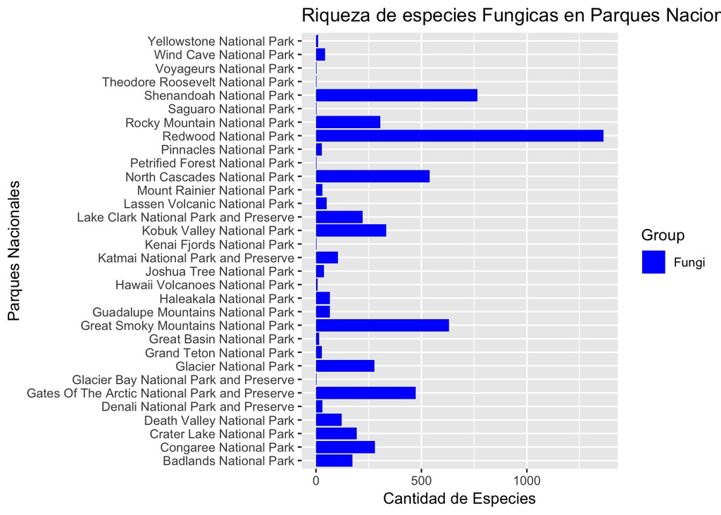

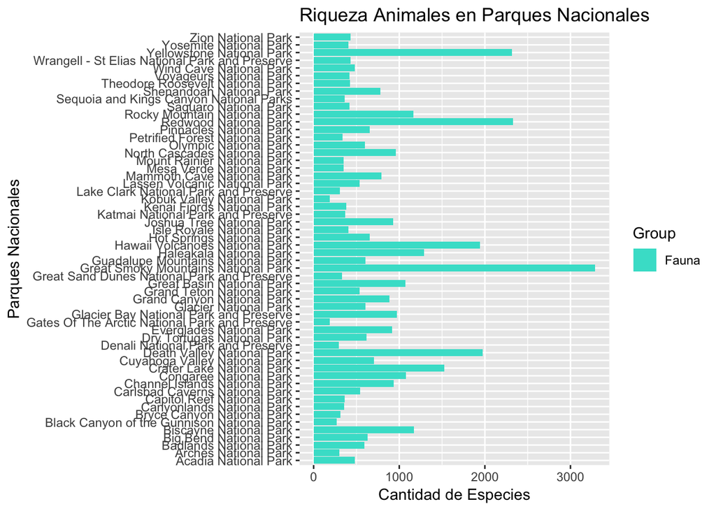

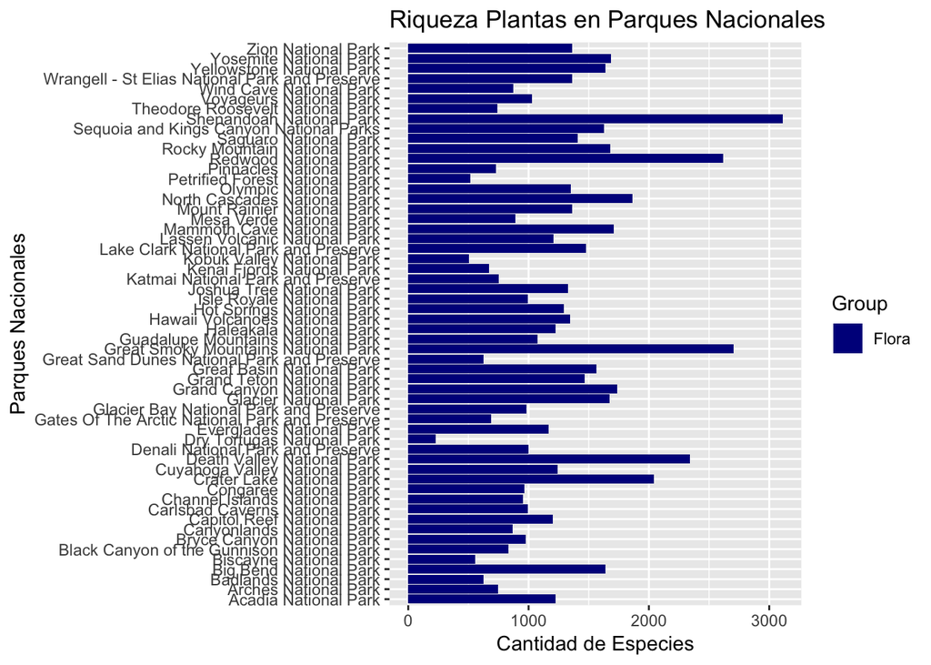

La composición diversa de especies muestra una tendencia en la riqueza de especies vegetales, por sobre las animales y fúngicas, siendo ésta la menos abundante. Cabe destacar que hay ciertos parques como Great Smoky Mountains, Yellowstone y Hawaii Volcanoes donde hay mayor riqueza de animales.  
Para vizualizar mejor las diferencias entre parques, el siguiente gráfico unifica la riqueza de especies en las 3 categorías señaladas por Parque.

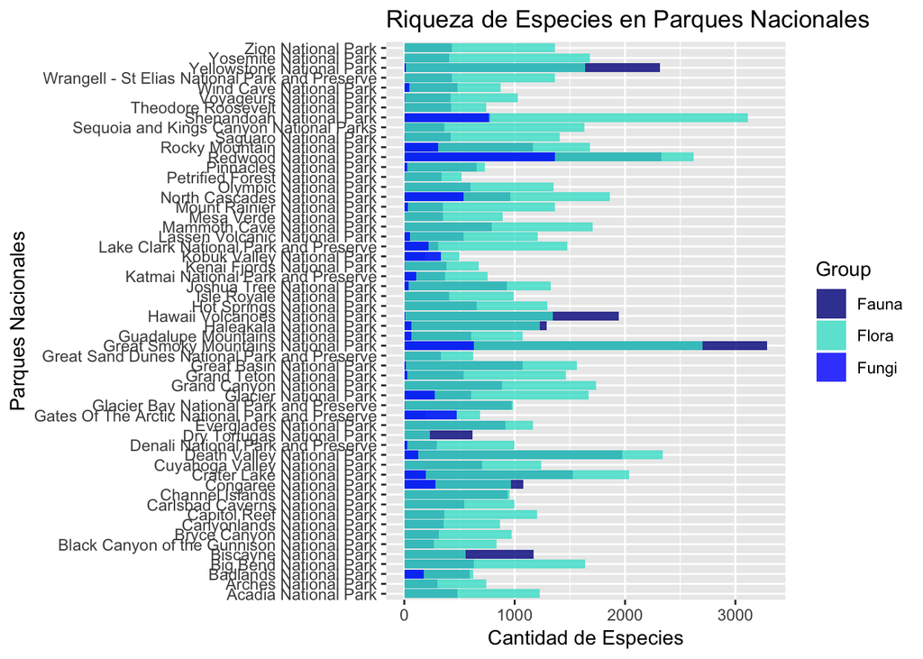

Para mayor información acerca de alguna especie en particular, revisar el siguiente [Link](https://www.biodiversitylibrary.org)